# MutSigCV pipeline

WU Fengyuan[^1]

2021/9/28

## Overview

MutSig stands for “Mutation Significance”. MutSig analyzes lists of mutations discovered in DNA sequencing, to identify genes that were mutated more often than expected by chance given background mutation processes. MutSigCV is the most current version of the algorithm. The “CV” stands for “covariates”.  
MutSigCV starts from the observation that the data is very sparse, and that there are usually too few silent mutations in a gene for its background mutation rate(BMR) to be estimated with any confidence. MutSigCV improves the BMR estimatation by pooling data from ‘neighbor’ genes in covariate space. These neighbor genes are chosen on the basis of having similar genomic properties to the central gene in question: properties such as DNA replication time, chromatin state (open/closed), and general level of transcription activity (e.g. highly transcribed vs. not transcribed at all).

## Pipeline

**1.Input files**

[output not shown]

**2.Merge MAF files**

Merge MAF files of different samples and select columns at the same time.

```r
echo -e "Hugo_Symbol\tChromosome\tStart_Position\tEnd_Position\tVariant_Classification\tVariant_Type\tReference_Allele\tTumor_Seq_Allele1\tTumor_Seq_Allele2\tTumor_Sample_Barcode\tt_alt_count\tt_ref_count" > test.funcotated.maf
for file in `find $mutect_dir -name "*.maf"`
do
awk -F '\t' -v OFS='\t' '!/^#/{print $1,$5,$6,$7,$9,$11,$12,$13,$16,$81,$82}' $file|sed '1d' >> test.funcotated.maf
done
```

**3.Run MutSigCV**

```r
MutSigCV_1.41/run_MutSigCV.sh \
MutSigCV_1.41/MCR_R2016a_glnxa64/v901 \ ## matlab enviroment
test.funcotated.maf \ ## input maf file
exome_full192.coverage.txt \
gene.covariates.txt \
TEST \ ## prefix of output files
mutation_type_dictionary_file.txt \
chr_files_hg19 ## reference genome
```

```r
library(maftools)
maf=read.maf(maf="test.funcotated.maf")
```

```
## -Reading
## -Validating
## --Removed 7 duplicated variants
## --Non MAF specific values in Variant_Classification column:
##   START_CODON_SNP
##   DE_NOVO_START_IN_FRAME
##   START_CODON_INS
##   DE_NOVO_START_OUT_FRAME
##   COULD_NOT_DETERMINE
## -Silent variants: 25502
## -Summarizing
## --Possible FLAGS among top ten genes:
##   TTN
##   MUC16
##   SYNE1
##   DNAH11
##   MACF1
##   NEB
## -Processing clinical data
## --Missing clinical data
## -Finished in 3.220s elapsed (2.950s cpu)
```

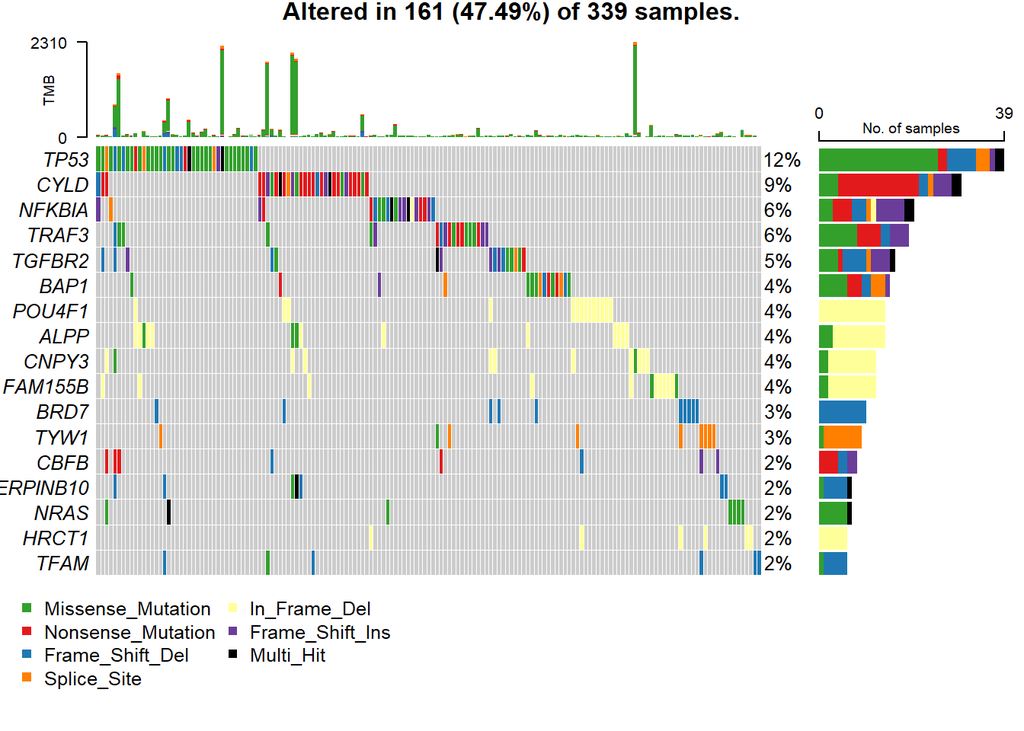

```r
sig=read.table("TEST.sig_genes.txt",header=T)
driver=sig[which(sig$q<0.1),]$gene
oncoplot(maf,genes=driver,showTumorSampleBarcodes=F)
```

For customized plotting, use `oncoPrint` from R package `ComplexHeatmap`.

## Results and Q&A

**1.test.sig_genes.txt**

| Columns | Description |
| --- | --- |
| gene | Gene symbols |
| expr | Expression level of this gene, averaged across 91 cell lines in the Cancer Cell Line Encyclopedia. |
| reptime | replication time of this gene (measured in HeLa cells), ranging from 100 (very early) to 1000 (very late). |
| hic | chromatin state of this gene (measured from HiC experiments in K562 cells) ranging from −50 (very closed) to +50 (very open). |
| N_nonsilent,silent,noncoding | Coverage of mutations in this gene. |
| n_nonsilent,silent,noncoding | Number of mutations in this gene. |
| nnei | Number of neighboring genes that are pooled together to compute the background mutation rate for that gene. |
| x | Number of mutated bases in these neighboring genes that are either silent or non-coding. |
| X | Total number of bases related to these neighboring genes. |
| p | p values |
| q | FDR adjusted p values |

**2.p and q value**

For example, suppose that among 10,000 genes tested, 1,000 are actually differentially expressed and 9,000 are not:  
Distribution of p values of genes which are not differently expressed uniform. So if we consider every gene with a p-value of less than 0.05 to be differentially expressed, we expect that 450 (5%) of the 9,000 genes that are not differentially expressed will appear to be differentially expressed (450 false positives).  
If we control the pFDR to 0.05 by considering all genes with a q-value of less than 0.05 to be differentially expressed, then we expect 5% of the positive results to be false positives (e.g. 900 true positives, 45 false positives, 100 false negatives, 8,955 true negatives). This strategy enables one to obtain relatively low numbers of both false positives and false negatives.

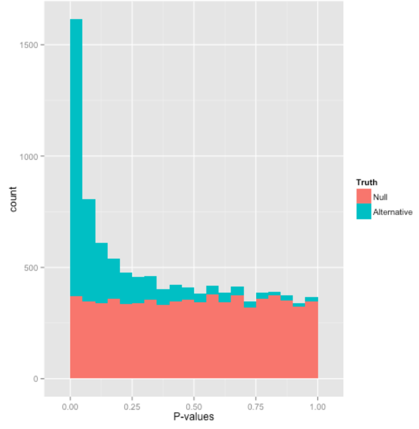

[^1]: Institute of Zoology, CAS wufengyuan@ioz.ac.cn